# Mapping out invasive-related proteins in HNSCC

Sara Gosline

6/30/2021

## Background

We are searching for proteins that can predict lymph node status to use to build our model. We will start with a supervised approach that selects proteins known to be involved in invasiveness from Poliquent et al. First we just load the proteomics data that we have.

|  | Stats | Counts |
| --- | --- | --- |
| 1 | Patients with tumor data | 110 |
| 2 | Patients with normal data | 66 |
| 3 | Patients with imaging data | 60 |

Now that we have the genes and the samples aligned we can begin to analyze them more broadly.

## Visualize samples by patient clustered by tumor abundance

We now want to see how the patients fall across the various variables. We can first evaluate how well the proteins separate out patients by lymph node status using a three state model or a two state model.

```r
##quick function to do PCA on a column value
pcaFromDf<-function(df,column){
  mat <-df%>%
    dplyr::select('Gene','patient',column)%>%
    pivot_wider(names_from='patient',values_from=column)%>%
    tibble::column_to_rownames('Gene')%>%
    as.matrix()
  return(data.frame(prcomp(t(mat))$x)%>%tibble::rownames_to_column('patient'))
}

##let's first do a PCA plotted with positive lns
tumAbund <- pcaFromDf(fullProts,'inferredTumAbund')%>%
  left_join(clin.dat,by='patient')%>%
  left_join(select(red.dat,c(patient,lnCounts,lnSpread)),by='patient')
```

```
## Note: Using an external vector in selections is ambiguous.
## i Use `all_of(column)` instead of `column` to silence this message.
## i See <https://tidyselect.r-lib.org/reference/faq-external-vector.html>.
```

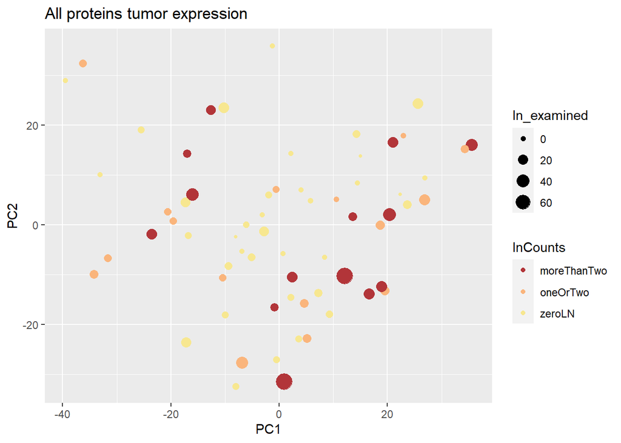

```r
##all proteins
ggplot(tumAbund)+
  geom_point(aes(x=PC1,y=PC2,size=ln_examined,col=lnCounts))+
  ggtitle('All proteins tumor expression')+scale_color_manual(values=pal)
```

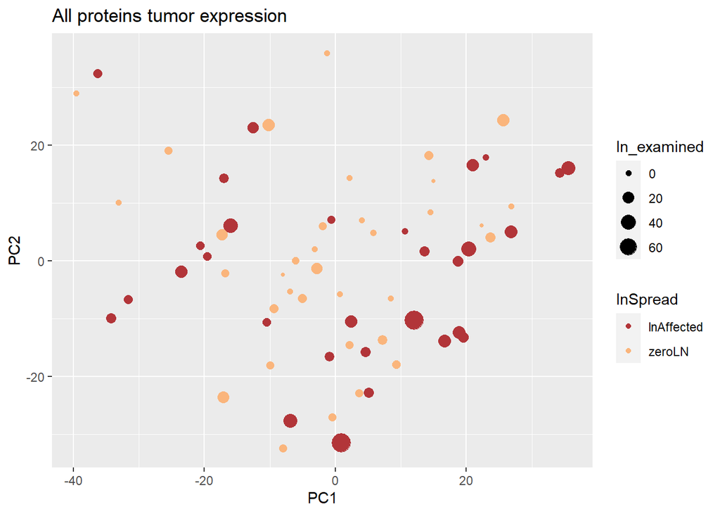

```r
##all proteins
ggplot(tumAbund)+
  geom_point(aes(x=PC1,y=PC2,size=ln_examined,col=lnSpread))+
  ggtitle('All proteins tumor expression')+scale_color_manual(values=pal)
```

It’s clear that the tumor proteins don’t really cluster by LN status when analyzed all in bulk. It’s worthwhile to investigate the normal proteins however. So we can plot normal protein expression here.

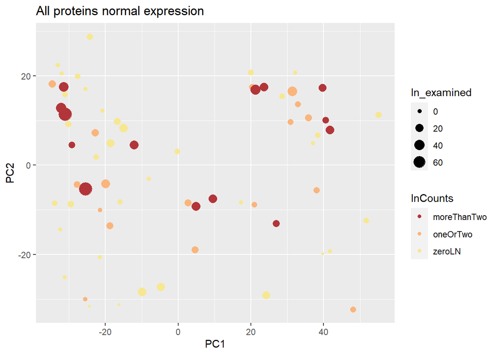

```r
normAbund <- pcaFromDf(normProts,'inferredNormAbund')%>%
  left_join(clin.dat,by='patient')%>%
  left_join(select(red.dat,c(patient,lnCounts,lnSpread)),by='patient')

##now let's plot ll proteins normal expression
ggplot(normAbund)+
  geom_point(aes(x=PC1,y=PC2,size=ln_examined,col=lnCounts))+
  ggtitle('All proteins normal expression')+scale_color_manual(values=pal)
```

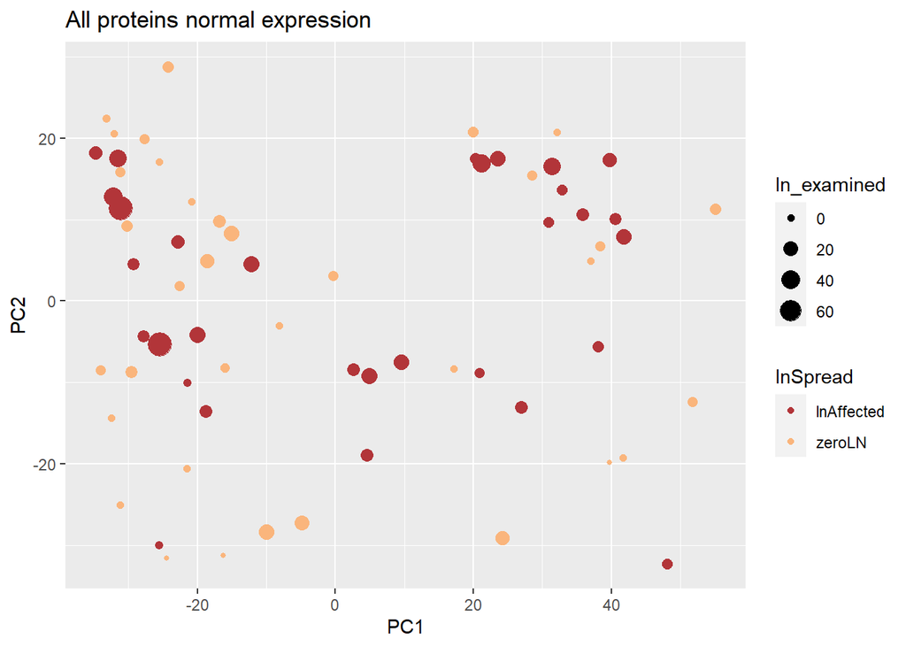

```r
##now let's plot ll proteins normal expression
ggplot(normAbund)+
  geom_point(aes(x=PC1,y=PC2,size=ln_examined,col=lnSpread))+
  ggtitle('All proteins normal expression')+scale_color_manual(values=pal)
```

We can see if differences between tumor and normal are indicative as well.

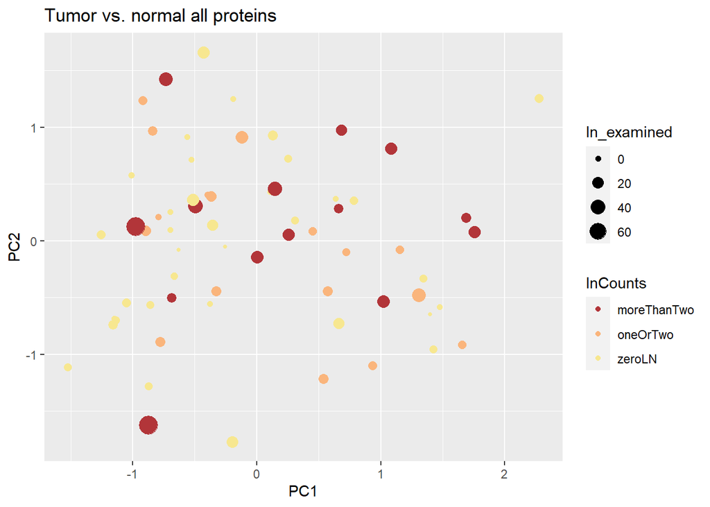

```r
##let's first do a PCA plotted with positive lns
tumNorm <- pcaFromDf(fullProts,'tumNormDiff')%>%
  left_join(clin.dat,by='patient')%>%
  left_join(select(red.dat,c(patient,lnCounts,lnSpread)),by='patient')


##all proteins
ggplot(tumNorm)+
  geom_point(aes(x=PC1,y=PC2,col=lnCounts,size=ln_examined))+
  ggtitle('Tumor vs. normal all proteins')+scale_color_manual(values=pal)
```

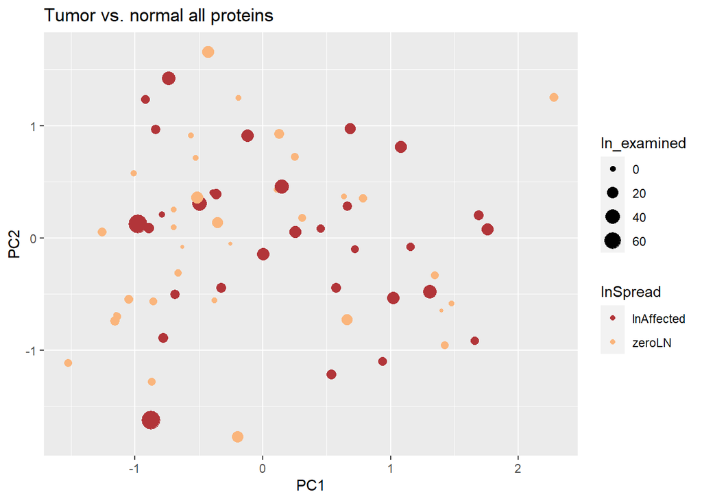

```r
##all proteins
ggplot(tumNorm)+
  geom_point(aes(x=PC1,y=PC2,col=lnSpread,size=ln_examined))+
  ggtitle('Tumor vs. normal all proteins')+scale_color_manual(values=pal)
```

## Selected invasion proteins

We have a set of proteins that are known to be related to invasivity - do they cluster the samples any better?

Do we see any difference in clustering/staining with invasivity, doing all the tests as we did above.

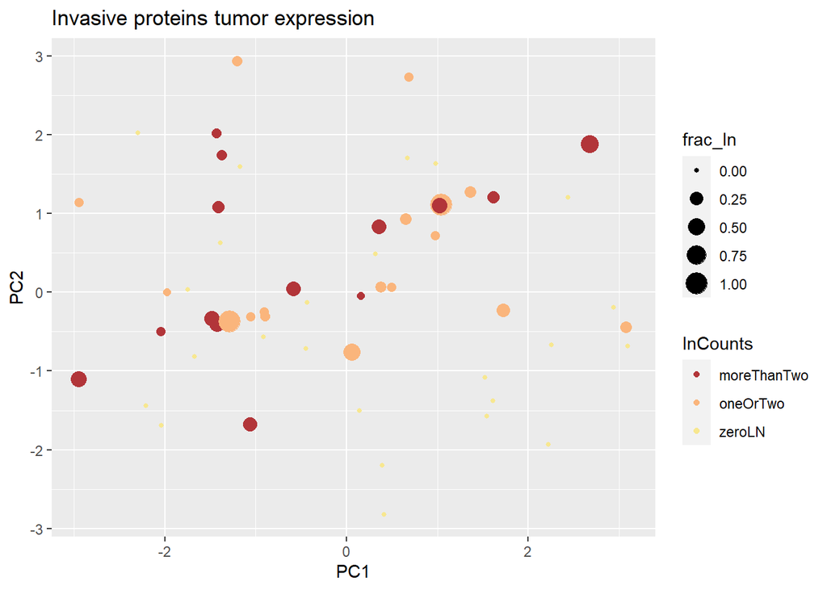

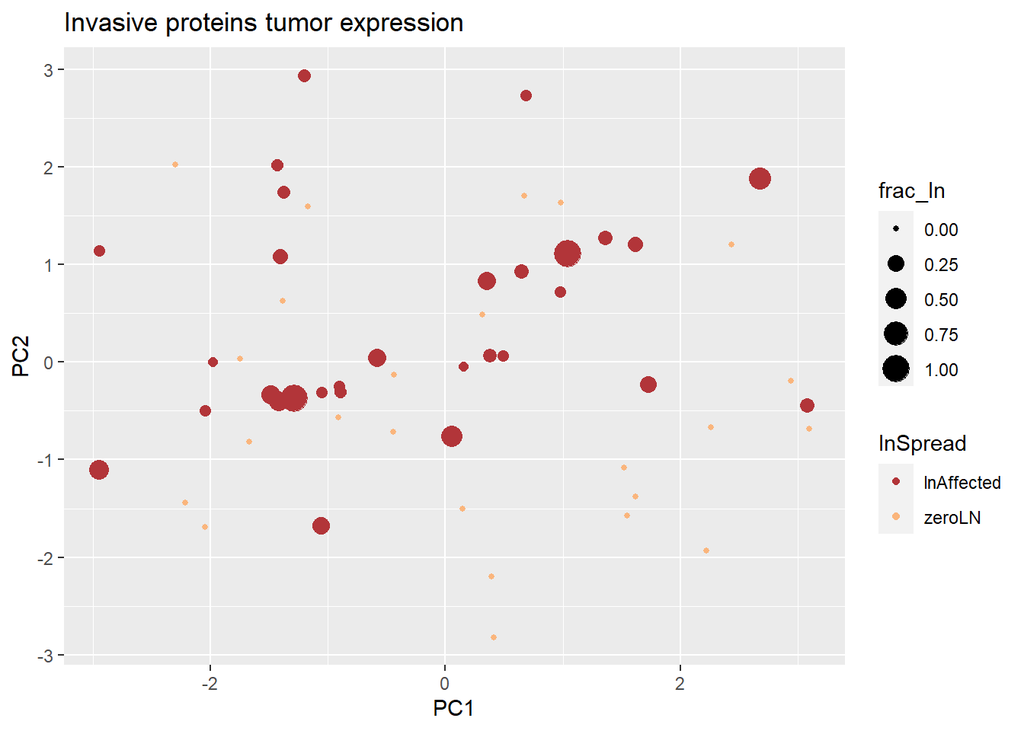

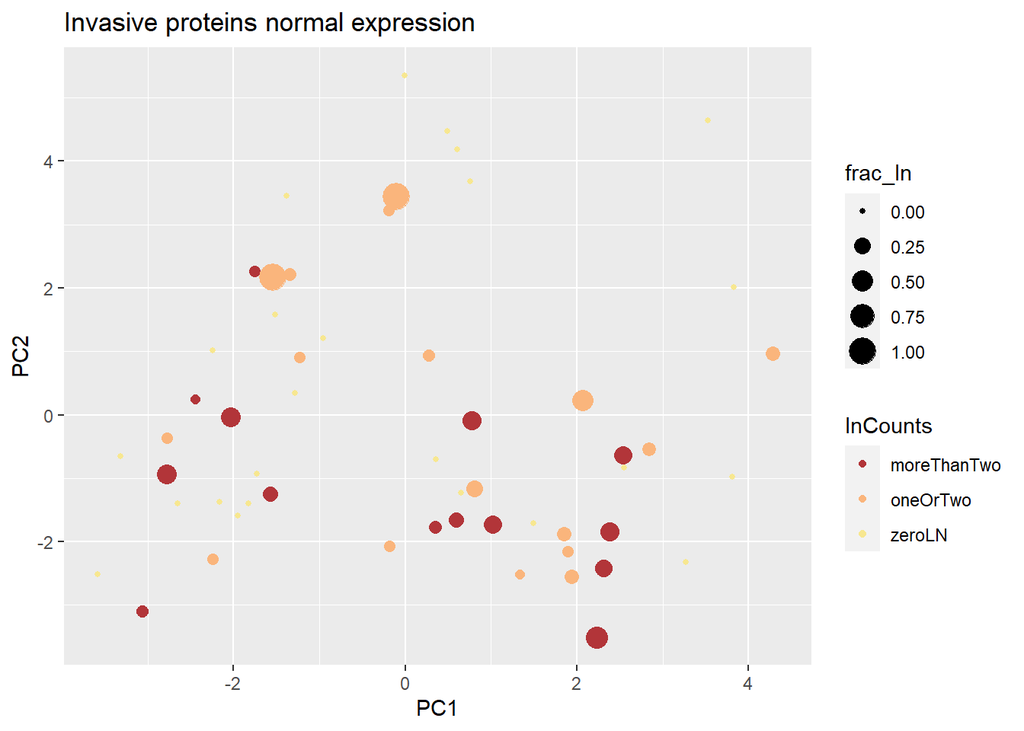

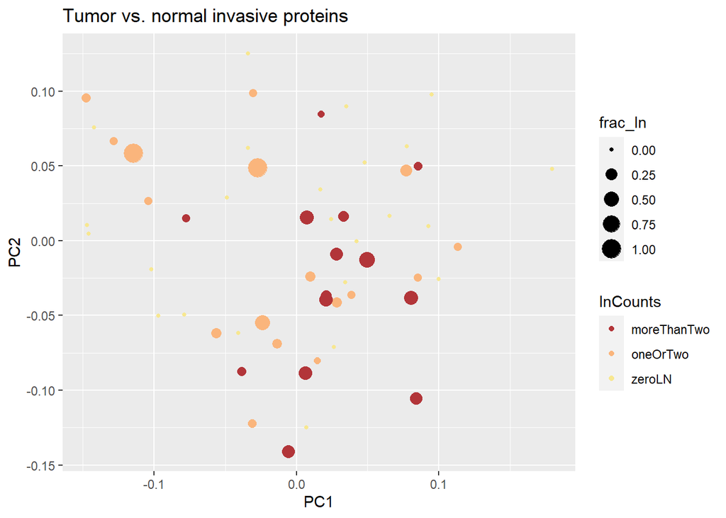

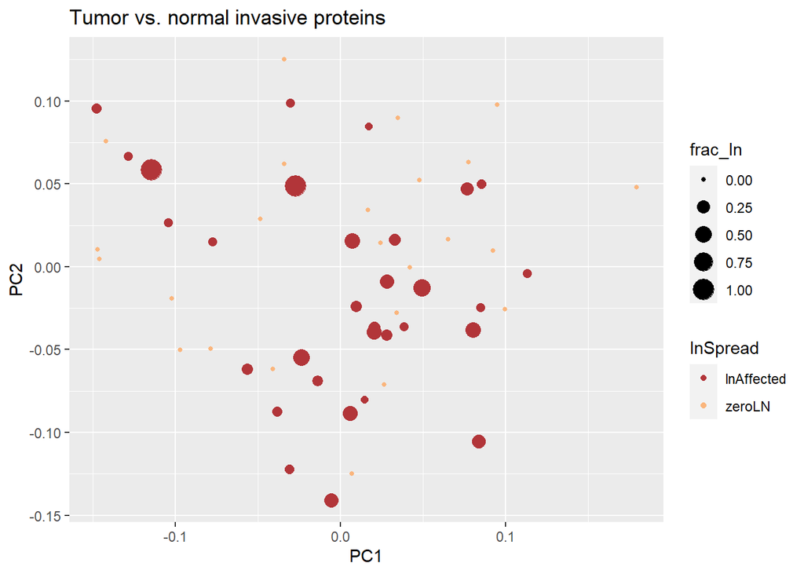

## Conclusion

There is no clear separation between samples based on all proteins or invasive proteins in this supervised fashion.